# The Pressure Cooker:

July 18, 2016

## The relationship between population density and crime rates is not straightforward

Cities are pressure cookers: if you squeeze people together, crime rates go up. After all, in the country, you wouldn't shoot your neighbor, right?

But everyone knows that you'd rather not be in a subway station alone late at night. More people around make it less likely you'll be mugged.

So which is it? Does crime increase or decrease with population density?

## The population density in NYC counties is an order of magnitude higher than the rest of New York's counties

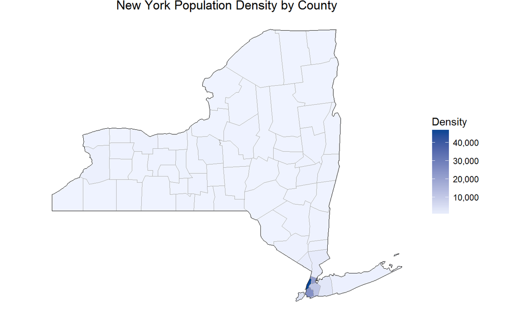

## The population density in NYC counties is an order of magnitude higher than the rest of New York's counties

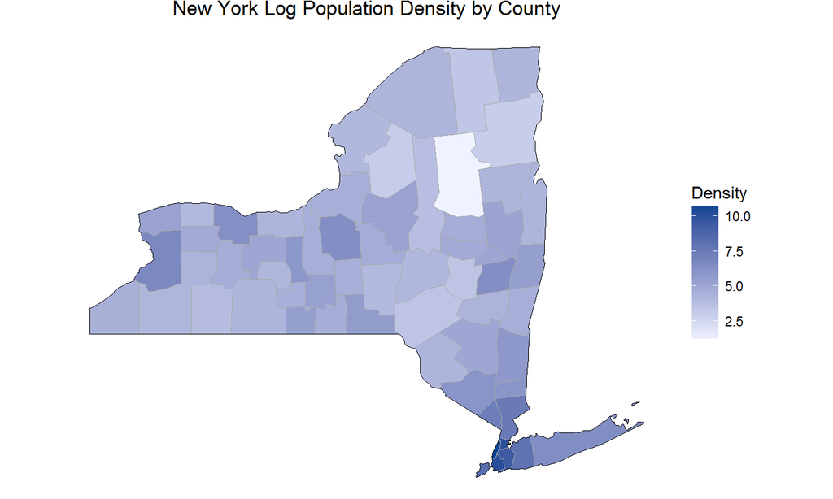

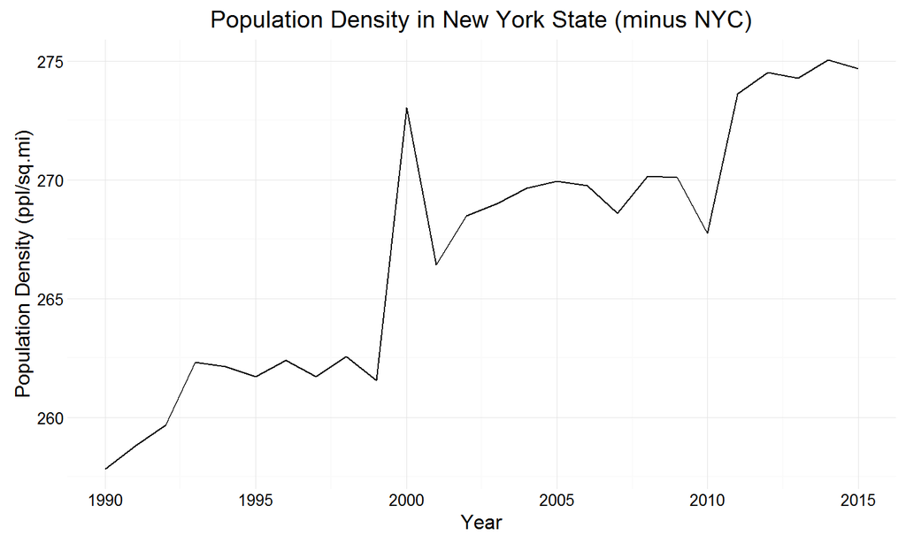

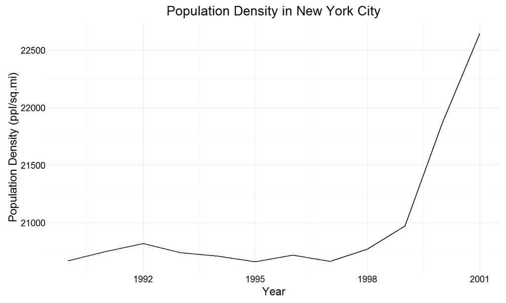

## Four measures of crime rate have all decreased in the past 25 years in New York State

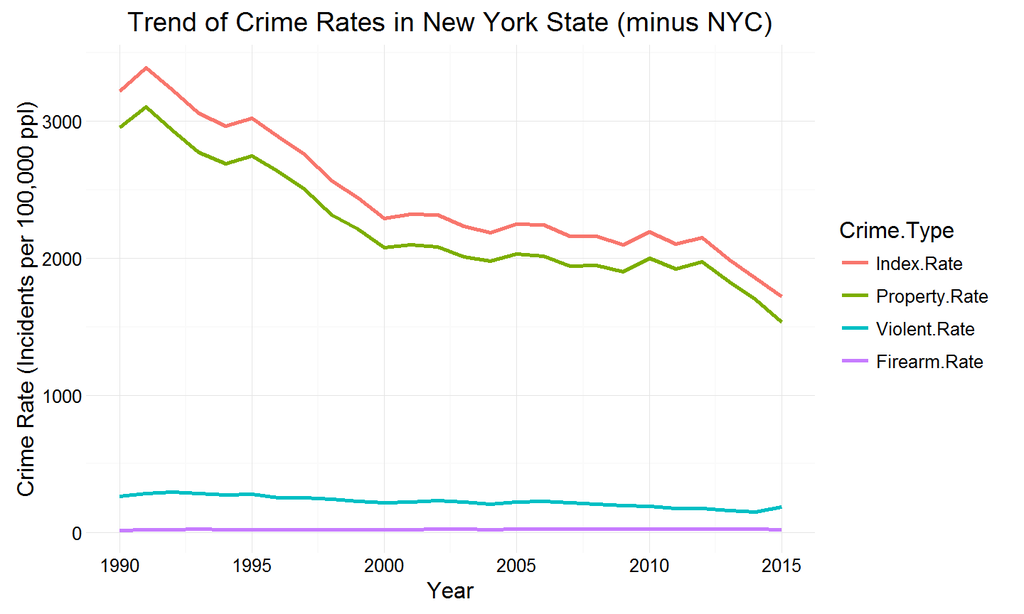

## Four measures of crime rate also decreased during the 1990s in NYC

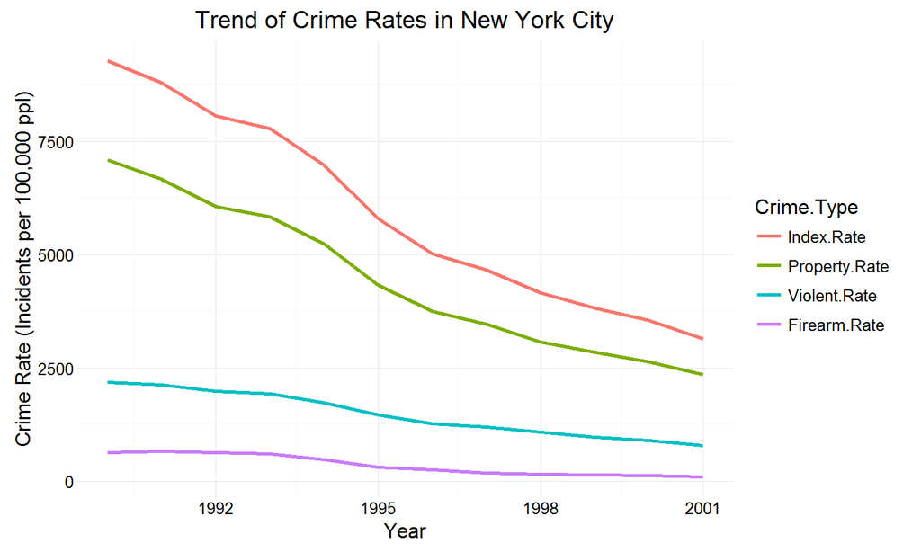

## The crime rates rose with population density outside NYC when it remains under 500

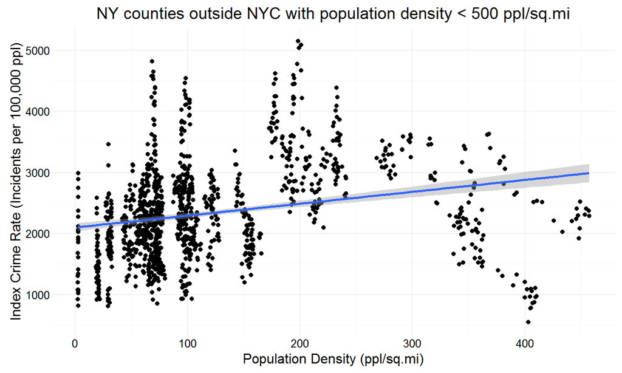

## Crime rates did not increase with population density above 500 outside NYC

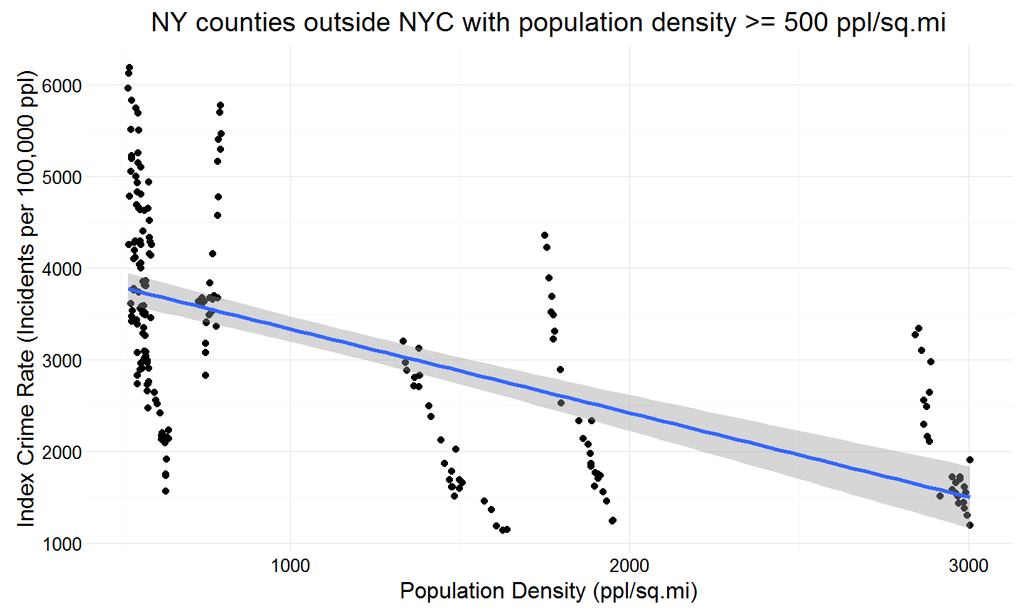

## The index crime rate rises with population density in NYC

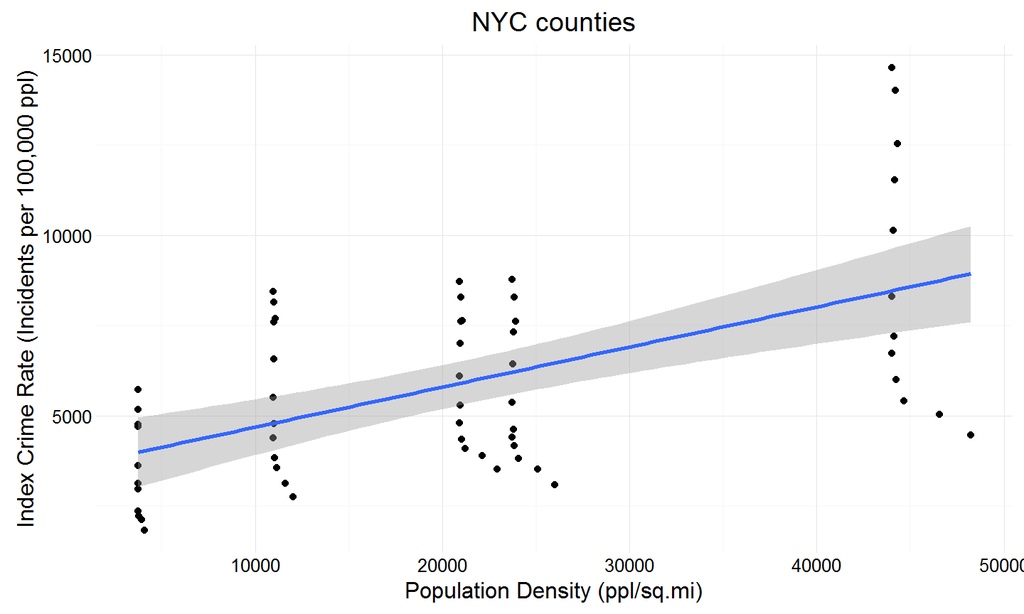

## Takeaway

- Population density in NY state has increased over the last 25 years
- Crime rates in NY state have decreased over the last 25 years
- In NYC counties, crime rates increase with population density
- In counties outside NYC, an increase in crime rates appears with an increase in population density, but only up to 500 ppl/sq.mi, where it then appears to decrease

## Future Work

Household income, racial diversity, age, and education are all variables which intuitively could impact crime rates for which there is available data. Expanding the investigation to account of those variables would shed more light on the factors affecting crime rates and help guide policy decisions.